# Financial Analysis with Python

# Indroduction

Python has achieved a paramount position in the financial sector, driven by its exceptional adaptability, computational efficacy, and a broad, specialized library ecosystem. Its inherent clarity and seamless integration capabilities establish it as the definitive programming language for the rapid construction and deployment of sophisticated quantitative models, substantially enhancing capabilities across the finance industry.The central objective of this endeavor is to develop an in-depth, applied instructional guide utilizing Python for rigorous financial analysis. The scope of the study will concentrate on leveraging key libraries to evaluate the historical market behavior and risk exposure of leading Indian Stock Market Indices specifically the benchmark Nifty 50 (NSEI), the foundational BSE Sensex (BSESN), and the sector-specific Nifty Bank (NSEBANK) spanning the years 2017 through 2024.The deliverable of this project will be a methodological, step-by-step framework for processing financial time-series data, precisely quantifying critical performance indicators such as Annualized Volatility and Cumulative Returns, and graphically representing these findings to deliver a comprehensive market assessment.

# Background

To achieve this, I will perform a thorough financial analysis of various key stock indexes across India, more precisely:

Nifty 50 (^NSEI): (The benchmark index of the National Stock Exchange (NSE), representing the 50 largest Indian companies.)

BSE Sensex (^BSESN): (The benchmark index of the Bombay Stock Exchange (BSE), representing the top 30 blue-chip Indian companies.)

Nifty Bank (^NSEBANK): (The index of the Indian banking sector, tracking the performance of the most liquid and large-capitalized Indian banking stocks.)

I plan to collect historical stock data from 2017 to 2024, aiming to recognize patterns and trends in market performance and volatility. Through a detailed analysis of metrics like Returns and Annualized Volatility, I aim to extract valuable insights that can shed light on the dynamics of the Indian equity market, providing a comprehensive understanding of the risk-reward trade-offs during this period.

# Project Outline

## Outline

- Importing the data
  - installing yfinance library
  - creating a dataframe
- Exploratory Data Analysis
- Data Visualization
  - Missing Values Visualization
  - Line Charts
  - Candlestick Charts
- Financial Analysis
  - Daily Returns
  - Average Daily Returns
  - Volatility

# Import Liabraries

```python
import pandas as pd
import numpy as np
import seaborn as sns; sns.set()
import matplotlib.pyplot as plt
```

## Importing the data

```python
import datetime
import yfinance as yf
```

After installing and importing `yfinance` I start by first specifying the **start** and the **end** dates using python datetime module.

```python
# Set the start and end dates for your analysis.
start_date = datetime.datetime(2017, 1, 1)
end_date = datetime.datetime(2024, 12, 31)
print(start_date)
print(end_date)
```

```
2017-01-01 00:00:00
2024-12-31 00:00:00
```

```python
# First, let's define a list with all the stock tickers
STOCK_INDEX = ['^NSEI', '^BSESN', '^NSEBANK']

print(stock_index)

# Then we create an empty data frame to store the data
stock_data = pd.DataFrame()

# We create a loop that downloads each stock index individually and then we appends it to the dataframe
for stock in stock_index:
    data = yf.download(
    stock,
    start=start_date,
    end=end_date,
    auto_adjust=True
)

    data.columns = [col[0] for col in data.columns]
    data = data.add_prefix(f"{stock}_")

    # concatenates the dataframes horizontally based on columns
    stock_data = pd.concat([stock_data, data], axis=1)

# Show the first rows of the dataframe
print(stock_data.head())

# Show the last rows of the dataframe
print(stock_data.tail())
```

```
[*********************100%***********************]  1 of 1 completed
[*********************100%***********************]  1 of 1 completed
[*********************100%***********************]  1 of 1 completed
```

```
['^NSEI', '^BSESN', '^NSEBANK']
            ^NSEI_Close   ^NSEI_High    ^NSEI_Low   ^NSEI_Open  ^NSEI_Volume  \
Date
2017-01-02  8179.500000  8212.000000  8133.799805  8210.099609      118300.0
2017-01-03  8192.250000  8219.099609  8148.600098  8196.049805      127300.0
2017-01-04  8190.500000  8218.500000  8180.899902  8202.650391      132400.0
2017-01-05  8273.799805  8282.650391  8223.700195  8226.650391      159100.0
2017-01-06  8243.799805  8306.849609  8233.250000  8281.849609      139400.0

            ^BSESN_Close   ^BSESN_High    ^BSESN_Low   ^BSESN_Open  \
Date
2017-01-02  26595.449219  26720.980469  26447.060547  26711.150391
2017-01-03  26643.240234  26724.400391  26488.369141  26616.919922
2017-01-04  26633.130859  26723.369141  26606.060547  26677.220703
2017-01-05  26878.240234  26917.210938  26738.419922  26738.419922
2017-01-06  26759.230469  27009.609375  26733.330078  26929.689453

            ^BSESN_Volume  ^NSEBANK_Close  ^NSEBANK_High  ^NSEBANK_Low  \
Date
2017-01-02         8000.0             NaN            NaN           NaN
2017-01-03         9800.0    18035.390625   18114.840876  17830.742606
2017-01-04         8100.0    17890.792969   18092.640242  17868.693615
2017-01-05         9800.0    18115.738281   18163.839284  17977.591452
2017-01-06         7800.0    18263.787109   18325.286393  18157.089134

            ^NSEBANK_Open  ^NSEBANK_Volume
Date
2017-01-02            NaN              NaN
2017-01-03   18002.541396              0.0
2017-01-04   18037.240493              0.0
2017-01-05   18000.540404              0.0
2017-01-06   18168.237442              0.0
             ^NSEI_Close    ^NSEI_High     ^NSEI_Low    ^NSEI_Open  \
Date
2024-12-23  23753.449219  23869.550781  23647.199219  23738.199219
2024-12-24  23727.650391  23867.650391  23685.150391  23769.099609
2024-12-26  23750.199219  23854.500000  23653.599609  23775.800781
2024-12-27  23813.400391  23938.849609  23800.599609  23801.400391
2024-12-30  23644.900391  23915.349609  23599.300781  23796.900391

```

[output cut: 8 more lines]

```
             ^BSESN_Open  ^BSESN_Volume  ^NSEBANK_Close  ^NSEBANK_High  \
Date
2024-12-23  78488.640625        10300.0    51317.601562   51417.351562
2024-12-24  78707.367188         6200.0    51233.000000   51382.101562
2024-12-26  78557.281250         5600.0    51170.699219   51740.000000
2024-12-27  78607.617188         7700.0    51311.300781   51628.449219
2024-12-30  78637.578125         8900.0    50952.750000   51979.750000

            ^NSEBANK_Low  ^NSEBANK_Open  ^NSEBANK_Volume
Date
2024-12-23  51030.398438   51044.398438         110800.0
2024-12-24  51137.500000   51314.949219         112000.0
2024-12-26  50951.800781   51395.800781            100.0
2024-12-27  51240.101562   51268.199219          78200.0
2024-12-30  50718.351562   51255.351562         316300.0
```

## Exploratory Data Anlysis

Now let's look at this DataFrame and get an idea of what our data looks like.

First, let's use `shape` to get a better understanding of our dataframe. Then, we use `info()` method to get a summary of the DataFrame, including information about the data types, non-null values and its structure.

```python
stock_data.shape
stock_data.info()
```

```
<class 'pandas.core.frame.DataFrame'>
DatetimeIndex: 1971 entries, 2017-01-02 to 2024-12-30
Data columns (total 15 columns):
 #   Column           Non-Null Count  Dtype
---  ------           --------------  -----
 0   ^NSEI_Close      1970 non-null   float64
 1   ^NSEI_High       1970 non-null   float64
 2   ^NSEI_Low        1970 non-null   float64
 3   ^NSEI_Open       1970 non-null   float64
 4   ^NSEI_Volume     1970 non-null   float64
 5   ^BSESN_Close     1968 non-null   float64
 6   ^BSESN_High      1968 non-null   float64
 7   ^BSESN_Low       1968 non-null   float64
 8   ^BSESN_Open      1968 non-null   float64
 9   ^BSESN_Volume    1968 non-null   float64
 10  ^NSEBANK_Close   1963 non-null   float64
 11  ^NSEBANK_High    1963 non-null   float64
 12  ^NSEBANK_Low     1963 non-null   float64
 13  ^NSEBANK_Open    1963 non-null   float64
 14  ^NSEBANK_Volume  1963 non-null   float64
dtypes: float64(15)
memory usage: 246.4 KB
```

Here, I can tell that I do not have the same amount of data for all the stock indices, but since it is not a significant difference, it will not give us any issues. However, it might suggest that we might have some missing data.

```python
stock_data.columns
```

```
Index(['^NSEI_Close', '^NSEI_High', '^NSEI_Low', '^NSEI_Open', '^NSEI_Volume',
       '^BSESN_Close', '^BSESN_High', '^BSESN_Low', '^BSESN_Open',
       '^BSESN_Volume', '^NSEBANK_Close', '^NSEBANK_High', '^NSEBANK_Low',
       '^NSEBANK_Open', '^NSEBANK_Volume'],
      dtype='object')
```

```python
stock_data.index
```

```
DatetimeIndex(['2017-01-02', '2017-01-03', '2017-01-04', '2017-01-05',
               '2017-01-06', '2017-01-09', '2017-01-10', '2017-01-11',
               '2017-01-12', '2017-01-13',
               ...
               '2024-12-16', '2024-12-17', '2024-12-18', '2024-12-19',
               '2024-12-20', '2024-12-23', '2024-12-24', '2024-12-26',
               '2024-12-27', '2024-12-30'],
              dtype='datetime64[ns]', name='Date', length=1971, freq=None)
```

Then, let's use `describe()` method to generate a descriptive statistics of the numerical columns. It It provides information such as mean, standard deviation, minimum, maximum, and quartile values.

```python
stock_data.describe()
```

|  | ^NSEI_Close | ^NSEI_High | ^NSEI_Low | ^NSEI_Open | ^NSEI_Volume | ^BSESN_Close | ^BSESN_High | ^BSESN_Low | ^BSESN_Open | ^BSESN_Volume | ^NSEBANK_Close | ^NSEBANK_High | ^NSEBANK_Low | ^NSEBANK_Open | ^NSEBANK_Volume |
| --- | --- | --- | --- | --- | --- | --- | --- | --- | --- | --- | --- | --- | --- | --- | --- |
| count | 1970.000000 | 1970.000000 | 1970.000000 | 1970.000000 | 1.970000e+03 | 1968.000000 | 1968.000000 | 1968.000000 | 1968.000000 | 1.968000e+03 | 1963.000000 | 1963.000000 | 1963.000000 | 1963.000000 | 1.963000e+03 |
| mean | 14819.636273 | 14897.384342 | 14737.601587 | 14829.782924 | 3.577333e+05 | 49369.278750 | 49639.271308 | 49097.548397 | 49409.251123 | 1.751253e+05 | 33705.864118 | 33955.710704 | 33449.527953 | 33724.043278 | 1.234005e+06 |
| std | 4686.668738 | 4703.876769 | 4668.098104 | 4687.565254 | 2.010482e+05 | 15586.976652 | 15641.641013 | 15523.932109 | 15582.300723 | 1.682886e+06 | 9388.224957 | 9419.251071 | 9358.010459 | 9388.440867 | 4.105690e+07 |
| min | 7610.250000 | 8036.950195 | 7511.100098 | 7735.149902 | 0.000000e+00 | 25981.240234 | 26720.980469 | 25638.900391 | 26499.810547 | 0.000000e+00 | 16917.453125 | 17681.493283 | 16116.062322 | 16759.754383 | 0.000000e+00 |
| 25% | 10768.549805 | 10815.899902 | 10718.412354 | 10781.137695 | 2.268250e+05 | 35712.061523 | 35911.999023 | 35511.068359 | 35816.131836 | 8.100000e+03 | 25686.125977 | 25803.175976 | 25541.351968 | 25693.126981 | 0.000000e+00 |
| 50% | 13974.625000 | 14010.924805 | 13862.425293 | 13958.299805 | 2.911000e+05 | 47511.503906 | 47761.201172 | 47176.369141 | 47445.044922 | 1.160000e+04 | 31998.529297 | 32186.676872 | 31770.431724 | 32082.527413 | 1.121000e+05 |
| 75% | 17997.437012 | 18086.875488 | 17883.262207 | 17974.499512 | 4.525500e+05 | 60612.228516 | 60815.681641 | 60203.079102 | 60550.312500 | 1.752500e+04 | 41328.908203 | 41632.375000 | 41155.459309 | 41433.108552 | 2.070500e+05 |
| max | 26216.050781 | 26277.349609 | 26151.400391 | 26248.250000 | 1.811000e+06 | 85836.117188 | 85978.250000 | 85474.578125 | 85893.843750 | 3.181510e+07 | 54375.351562 | 54467.351562 | 54010.898438 | 54338.699219 | 1.798102e+09 |

Let's assume that we would like to look say at all the adjusted closing prices for all of these stock indices.

```python
# Define the list of stock tickers as used during data import
stock_index = ['^NSEI', '^BSESN', '^NSEBANK']

# Construct the correct column names for 'Close' prices
close_column_names = [f"{stock}_Close" for stock in stock_index]

# Extract the closing prices using the correct column names
ajd_close_prices_data = stock_data[close_column_names]

print(ajd_close_prices_data.head())
print(ajd_close_prices_data.tail())
```

```
            ^NSEI_Close  ^BSESN_Close  ^NSEBANK_Close
Date
2017-01-02  8179.500000  26595.449219             NaN
2017-01-03  8192.250000  26643.240234    18035.390625
2017-01-04  8190.500000  26633.130859    17890.792969
2017-01-05  8273.799805  26878.240234    18115.738281
2017-01-06  8243.799805  26759.230469    18263.787109
             ^NSEI_Close  ^BSESN_Close  ^NSEBANK_Close
Date
2024-12-23  23753.449219  78540.171875    51317.601562
2024-12-24  23727.650391  78472.867188    51233.000000
2024-12-26  23750.199219  78472.476562    51170.699219
2024-12-27  23813.400391  78699.070312    51311.300781
2024-12-30  23644.900391  78248.132812    50952.750000
```

# Data Visualization

### The Significance of Visual Analysis

Data visualization constitutes a critical phase in financial analysis, enabling the comprehension of large, complex datasets. Its significance is rooted in its ability to render intricate information highly accessible and intuitive through graphical representations.Visualization is not merely illustrative; it is analytical. It is essential for:Identifying Patterns and Trends: Charts and graphs readily expose long-term trends, market cycles, and latent relationships within the data that would remain obscured in tabular format (e.g., comparing the growth rates of NSEI versus NSEBANK).Data Quality Assessment: Visualization tools are invaluable for immediately flagging data quality issues, such as outliers, sudden price drops, or inconsistencies.Python's advantages in this domain are delivered by its robust visualization libraries, particularly Matplotlib, Seaborn, and Plotly. These tools offer deep customization, seamless integration with Pandas DataFrames, and the capability to generate sophisticated, interactive charts.Missing Values VisualizationBefore calculating returns or volatility, we must address the issue of data completeness. Given the results of our .info() check above, our merged DataFrame likely contains some missing data points (NaN), typically due to differing national market holidays between the indices.We can precisely visualize the location and extent of these gaps using the dedicated Python library, missingno.Action: If you have not already, please install the library by executing the following command in a code cell (or your terminal):Bash# Install the missingno library !pip install missingno Now, we will proceed to plot the missing data matrix for our Indian Indices.

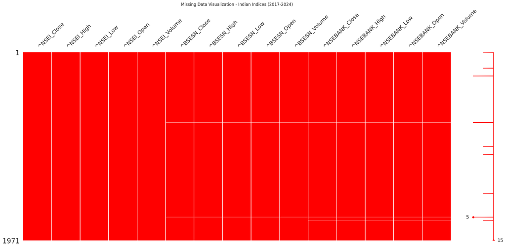

```python
import missingno as msno

# We plot the missing data
msno.matrix(stock_data, color=(1, 0, 0)) # Red color
plt.title('Missing Data Visualization - Indian Indices (2017-2024)')

plt.show()
```

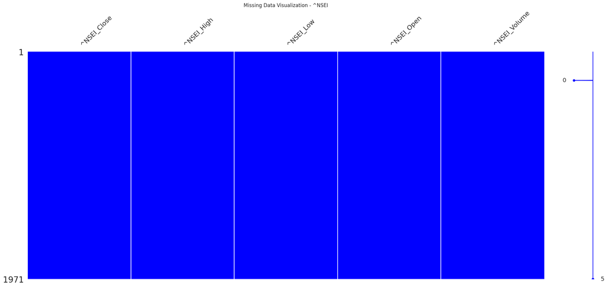

```python
MIB_data = stock_data.filter(like='^NSEI')

MIB_data.head()

# Plot the missing data
msno.matrix(MIB_data, color=(0, 0, 1)) # Blue color
plt.title('Missing Data Visualization - ^NSEI')

plt.show()
```

### Line Charts

Continuing forward, our next objective is to generate some line charts that show the movement of our data over time. This aims to explore potential trends or shifts in price movements.

We can use the previously generated data frames containing adjusted closing prices to create individual plot.

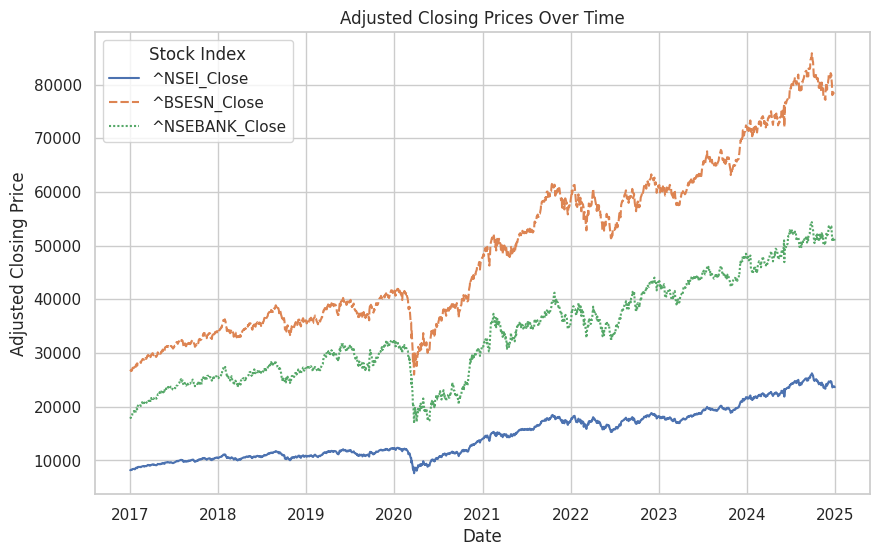

```python
sns.set(style="whitegrid")

# Plotting all adj closing prices with Seaborn
plt.figure(figsize=(10, 6))
sns.lineplot(data=ajd_close_prices_data)
plt.title('Adjusted Closing Prices Over Time')
plt.xlabel('Date')
plt.ylabel('Adjusted Closing Price')
plt.legend(title='Stock Index')
plt.show()
```

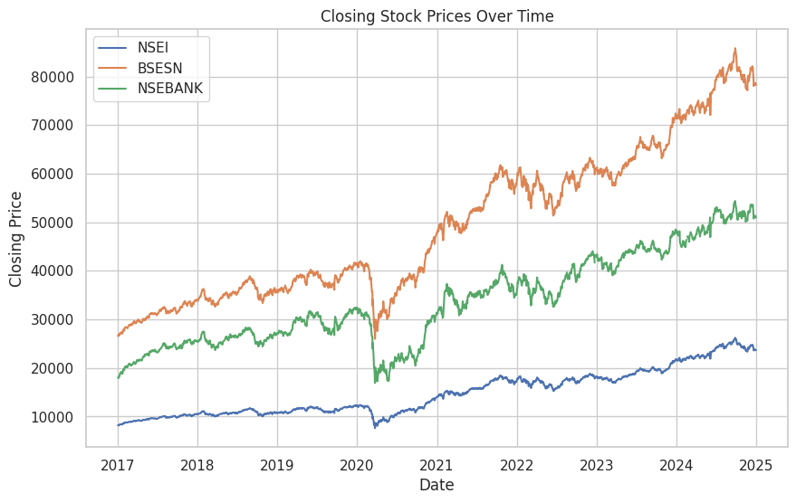

```python
plt.figure(figsize=(10, 6))

# Iterate through the stock_index and plot the correct 'Close' columns
for stock in stock_index:
    # Construct the exact column name
    column_name = f"{stock}_Close"
    # Get a more readable label for the legend by removing the '.MI' and '^' characters
    label = stock.replace('.MI', '').replace('^', '')
    plt.plot(stock_data[column_name], label=label)

plt.title('Closing Stock Prices Over Time')
plt.xlabel('Date')
plt.ylabel('Closing Price')
plt.legend()
plt.show()
```

### These line charts are crucial for effectively identifying long-term trends and critical market irregularities across the indices. They enable a direct visual comparison of the relative performance of the Nifty 50, BSE Sensex, and Nifty Bank over the 2017–2024 analysis period.

For example, observing the trends in the plotted data:We clearly observe a synchronized, sharp decline in prices across all stock indices during the March 2020 timeframe. This substantial market correction corresponds directly to the widespread fear and sell-off triggered by the onset of the global COVID-19 pandemic.Furthermore, it is evident from the chart that the Nifty Bank NSEBANK index generally experiences the most pronounced swings—both in periods of rapid growth and during crashes. This confirms the index's reputation for higher volatility and greater sensitivity to economic cycles compared to the broader, more diversified NSEI and BSESN .Candlestick ChartsAnother essential visualization tool is the candlestick chart.Candlestick charts are a foundational type of financial chart used to represent the full range of price movements of an asset over a specific time period (e.g., a day, week, or hour). They provide a dense, visual representation of price fluctuations that is extremely useful for identifying short-term trends and potential turning points.Each "candlestick" on the chart is a visual summary of four critical prices for that time interval: the open, close, high, and low prices.The candlestick has two main components:Body: The rectangular area between the open and close prices.If the close price is higher than the open price (a gain), the body is typically filled (often green).If the close price is lower than the open price (a loss), the body may be empty or colored differently (often red).Wicks or Shadows: The thin lines extending from the top and bottom of the body. They represent the highest and lowest prices achieved during the period.Candlestick charts are exceptionally popular in financial analysis because they offer a comprehensive and visually powerful way to interpret price action in financial markets. We use them here to focus on highly volatile periods, such as March 2020, to examine the intraday stress on the Indian markets.

Now, let's create candlestick charts for our stock indices. First we need to make sure we have the `plotly` library installed. If not, `pip install plotly` will do the job.

```python
import plotly.graph_objects as go

# Create candlestick chart for ^NSEI (Nifty 50 Index)
fig = go.Figure(data=[go.Candlestick(x=stock_data.index,
                open=stock_data["^NSEI_Open"],
                high=stock_data["^NSEI_High"],
                low=stock_data["^NSEI_Low"],
                close=stock_data["^NSEI_Close"])])

fig.update_layout(title='Candlestick Chart of ^NSEI Prices',
                  xaxis_title='Date',
                  yaxis_title='Price')

fig.show()
```

[interactive chart not shown]

If we want to take a look closely at a specific time frame, we can use `.loc()` to filter the index (which in our case is the date) and then repeat the steps above.

```python
s_date = '2020-03-01'
e_date = '2020-03-31'

# Filter DataFrame for March 2020
march_data = stock_data.loc[(stock_data.index >= s_date) & (stock_data.index <= e_date)]

# Create candlestick chart for March 2020
fig = go.Figure(data=[go.Candlestick(x=march_data.index,
                open=march_data["^NSEI_Open"],
                high=march_data["^NSEI_High"],
                low=march_data["^NSEI_Low"],
                close=march_data["^NSEI_Close"])])

fig.update_layout(title='Candlestick Chart of ^NSEI Prices - March 2020',
                  xaxis_title='Date',
                  yaxis_title='Price')

fig.show()
```

[interactive chart not shown]

# Financial Analysis and Metrics

## Return Analysis: The Foundation of Performance Measurement

Return analysis is the foundational pillar of evaluating investment performance. It involves the systematic examination of the gains or losses generated by an asset over a defined period. This process is essential for benchmarking performance, assessing the effectiveness of investment decisions, and ultimately quantifying success in the market.

#### Key aspects of this analysis typically include:

##### Calculating absolute and annualized returns.

##### Comparing performance against market benchmarks.

In this project, we begin by calculating the Daily Returns {r} for each of our Indian indices. By analyzing these daily fluctuations, we gain insights into the market's consistency and volatility across the 2017–2024 period.

#### Calculating Daily Returns ({r})

To calculate the daily percentage change in the closing price for our stock indices, we utilize the powerful .pct_change() function provided by the Pandas library. This function is specifically designed for time-series data and efficiently calculates the percentage difference between the current day's price and the previous day's price, establishing the basis for all subsequent risk and return metrics.